# Human Activity Recognition Prediction Model

# Background

Human Activity Recognition - HAR - has emerged as a key research area in the last years and is gaining increasing attention by the pervasive computing research community. One of the potential applications for HAR, is supporting weight-loss programs, and digital assistants for weight lifting exercises. The Weight Lifting Exercises dataset investigates “how (well)” an activity was performed by the wearer of the various sensors.

This assignment is an attempt at building a model which can accurately predict the class of an activity performed

# Prediction Study Design

The relative order of importance of the study will be as follows

question > data > features > algorithms > evaluation

Caret package will be used for this assignment

## 1. Question

This assignment consists of building a model that can predict the different fashions in which six participants performed 10 repetitions of the Unilateral Dumbbell Biceps Curl :

```
  * exactly according to the specification (Class A),

  * throwing the elbows to the front (Class B),

  * lifting the dumbbell only halfway (Class C),

  * lowering the dumbbell only halfway (Class D)

  * throwing the hips to the front (Class E)
```

## 2. Data and Features

The plan for data is as follows:

1. Read in the training data
2. Features:
   1. Identify all features that have “NA” and remove these columns
   2. Identify near zero variance columns and remove these columns
   3. Identify factor variables that are not needed for the analysis. Columns 1:6 are removed
3. Data Slicing: Data will be partitioned 75% training, 25% testing proportion. Once partitioned a check will be done to see if the classes are similarly spread across training and testing sets. Percentage distribution of classes across data partitions is as follows

|  | Original Distribution in % | Training set Distribution in % | Test set Distribution in % |
| --- | --- | --- | --- |
| A | 28.40 | 28.40 | 28.40 |
| B | 19.40 | 19.40 | 19.40 |
| C | 17.40 | 17.40 | 17.40 |
| D | 16.40 | 16.40 | 16.40 |
| E | 18.40 | 18.40 | 18.40 |

## 3. Algorithms

Three models will be used namely CART, Stochastic Gradient Boosting and Random Forest. The following steps will be carried out for each model.

- Tuning parameters will be set
- Center and Scale preprocessing will be used
- K Fold Cross validation will be used for each method
- Model plots will be drawn
- Predictions will be made using the testing partition
- Confusion Matrix will be drawn
- Accuracy of each model will be determined

### 3.1 CART

#### Confusion Matrix for CART

```
##           Reference
## Prediction    A    B    C    D    E
##          A 1286  409  387  341  136
##          B   17  312   26  134  137
##          C   90  228  442  329  242
##          D    0    0    0    0    0
##          E    2    0    0    0  386
```

#### CART plot

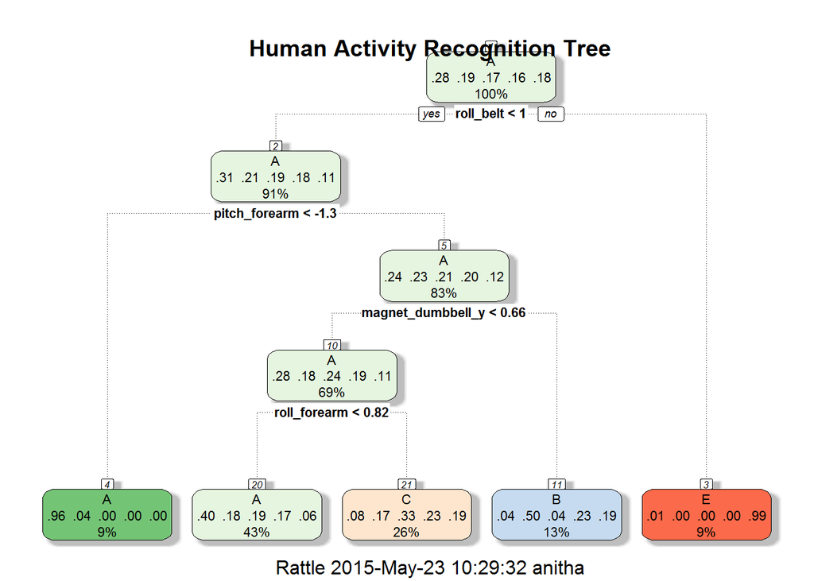

#### CART Accuracy

```
##      Accuracy         Kappa AccuracyLower AccuracyUpper  AccuracyNull
##     0.4946982     0.3394781     0.4806097     0.5087931     0.2844617
```

### 3.2 GBM

#### Confusion Matrix for GBM

```
##           Reference
## Prediction    A    B    C    D    E
##          A 1364   28    0    1    0
##          B   18  903   28    7   15
##          C    7   17  816   27   12
##          D    6    1   11  764   19
##          E    0    0    0    5  855
```

#### GBM plot

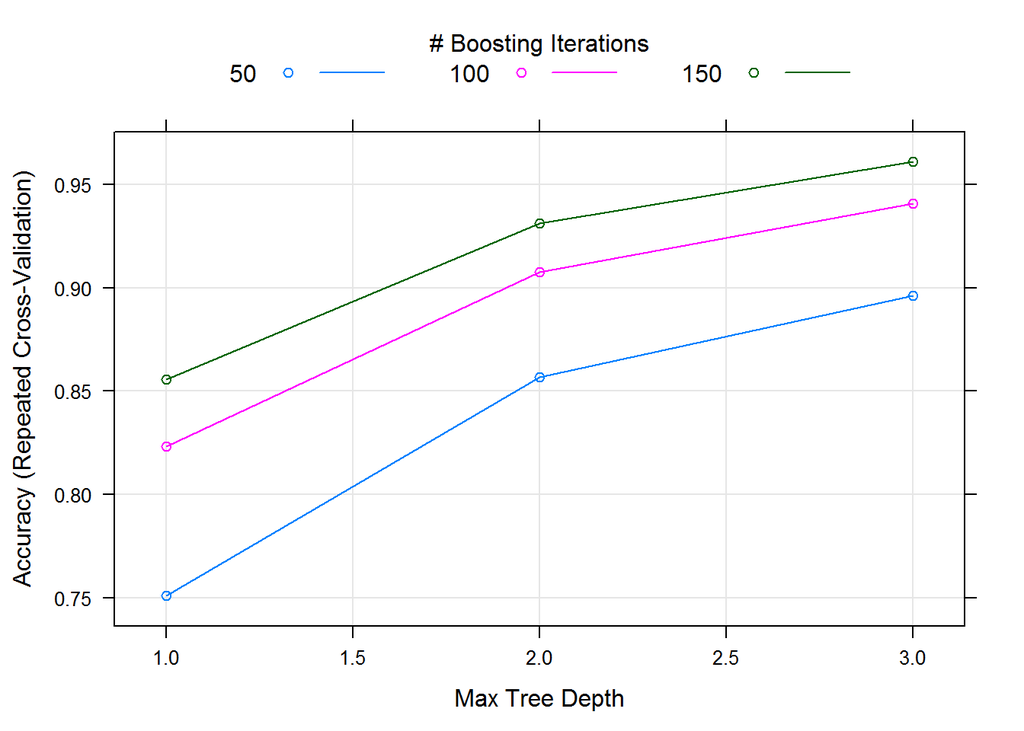

#### GBM Accuracy

```
##      Accuracy         Kappa AccuracyLower AccuracyUpper  AccuracyNull
##     0.9588091     0.9479014     0.9528654     0.9641985     0.2844617
```

### 3.3 Random Forest

#### Confusion Matrix for RF

```
##           Reference
## Prediction    A    B    C    D    E
##          A 1394    3    0    0    0
##          B    0  943    1    1    0
##          C    1    3  850   13    0
##          D    0    0    4  790    8
##          E    0    0    0    0  893
```

#### RF plot

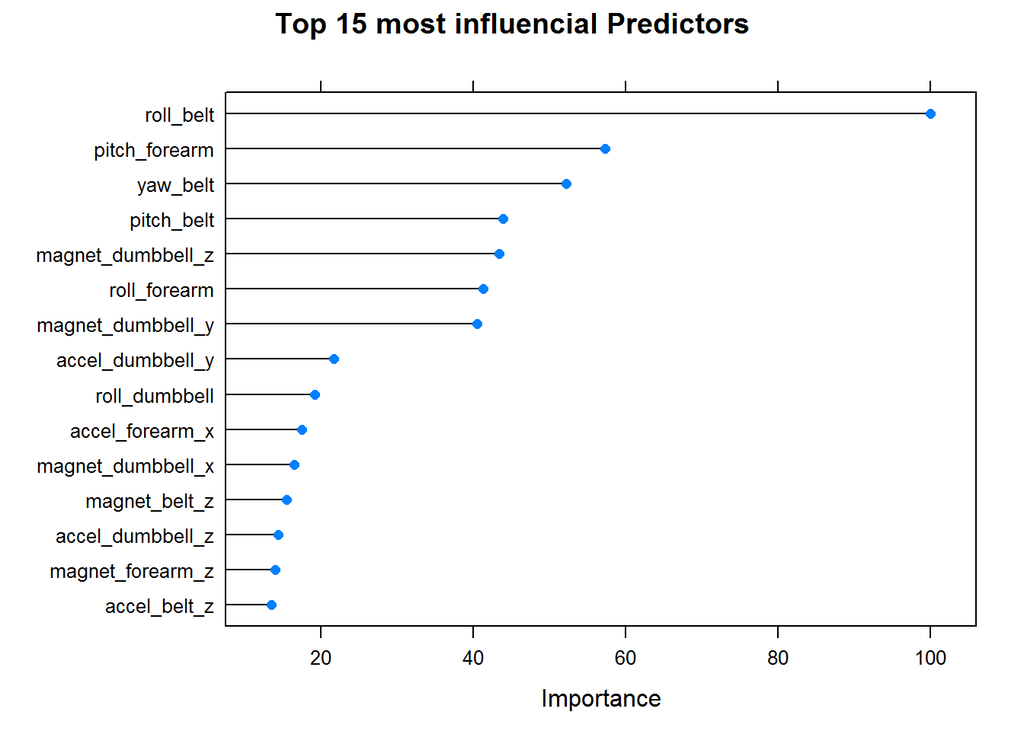

#### RF Accuracy

```
##      Accuracy         Kappa AccuracyLower AccuracyUpper  AccuracyNull
##     0.9930669     0.9912304     0.9903250     0.9951940     0.2844617
```

## 4.Evaluation

Comparison of the 3 models:

```
##      TrueNegative TruePositive FalseNegative FalsePositive  Accuracy
## CART         1286          312           409            17 0.4946982
## GBM          1364          903            28            18 0.9588091
## RF           1394          943             3             0 0.9930669
```

The Random Forest model wins with an accuracy of 99% !